# Your Digest for Monday, Oct 16, 2023 11:59 PM

📑Nail changes in psoriasis:

- *splinter haemorrhages* (is a recognized sign)

# Q 7: 📑Erythema nodosum

- 📑Streptococcal infection
- 📑Leprosy
  - 📑Erythema nodosum **does not occur** in tuberculoid leprosy.
- 📑Systemic diseases -> Sarcoidosis, behcet, inflammatory bowel disease  
  Commonest : anterior shins ; heals without scarring, it 📑 **never** ulcerates.  
  #2020GM-JUL/Q42NoNumber

Tuberculoid to lepromatous is a spectrum. **Lepromatous** is the severe form.  
Tuberculoid

- **Few hypopigmented patches only** and *some nerve involvement*.
- Tuberculoid form is **not infectious**.

*Immune suppressed persons* will get **lepromatous leprosy**.

- **Multibacillary** - 12 months (rifampicin 600 monthly, clofaziime 300 monthly, dapsone daily. )
- **Paucibacillary** - 6 months (Rifampicin 600, dapsone ?daily)

MDT treatment should not be stopped for 'lepra' reactions (see below)

- type 1 reactions : existing lesions become red and nerve reactions  
  **These are not drug reactions**; *treatment is continued*. (unless a drug reaction occurs)

Even skin biopsy is not needed if clinically very suggestive of leprosy.  
📑

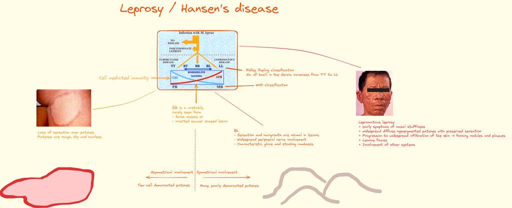

*In BL and LL leprosy, sensation and hair are preserved in the lesions*!  
There are type 1 and 2 lepra reactions.  
Can even occur **years after treatment is completed**.

Both share symptoms of **neuritis, arthritis, iritis and nasopharyngeal symptoms**.  
Can lead to **severe nerve injury with subsequence paralysis and deformity**.

- *Usually occurs* in **borderline disease** (BT-BL)
- **Induration, swelling or erythema of previous lesions**.
- appears to result from *spontaneous enhancement of cellular immunity* and delayed-type hypersensitivity to *M. leprae* antigens
- May rupture and discharge pus but they contain only dead bacteria and neutrophils -> **sterile on culture**.
- *Biopsy of lesions will show polymorph* -> **diagnostic of type 2 reactions**. (polymorphs not present in other lepromatous lesions).
- Occurs in Lepromatous or Borderline lepromatous disease.
- *Lucio phenomenon*: very rare; occurs in Mexicans. Necrotising punched punched out ulcers. Can be life threatening.  
  M leprae is an *obligate, intracellular parasite* -> **can't be cultured** on normal media.  
  Clofazimine causes a copper (red and dark skin and hair) pigmentation, particularly on *areas exposed to light* starting during the first 10 weeks of treatment. This is **reversible** but takes several months. Also causes *icthyosis*.

# 📑Erythema marginatum

#2020GM-JUL/Q33  
📑Seen most commonly in *early stages* of acute rheumatic fever [[Bacterial pathogens#GAS]].  
*Middle of the lesion shows resolution*. External edge is sharp, internal edge is blurred.

#2020GM-JUL/Q33

[output not shown]

- **Triad** of **ophthalmoplegia, ataxia, confusion**, + nystagmus + lower limb polyneuropathy.
- Is an **acute condition**; Reversible; requires emergency treatment to prevent death.
- Occurs in chronic alcoholics and *after bariatric surgery*.
- Other causes: severe malnutrition, *hyperemesis gravidarum*, prolonged parenteral nutrition (without thiamine), malignancies, immunodeficiency syndromes, liver disease, hyperthyroidism, and severe anorexia nervosa.

> [!TIP] Kor - chronic  
> 📑Anterograde amnesia (AA) - can't learn new things  
> 📑 Dry beriberi is the development of a *symmetrical peripheral neuropathy characterized by both **sensory** and **motor** impairments*, mostly of the distal extremities.(peripheral neuropathy, muscle weakness, *brisk tendon reflexes*, seizures).  
> 📑 Wet beriberi includes signs of **cardiac involvement** with *cardiomegaly*, *cardiomyopathy*, **High output heart failure**, peripheral edema, and tachycardia, *in addition to neuropathy*

# Zinc deficiency

- Zinc acts as a catalyst and as a structural component by binding strongly to some amino acids.
- Historically, zinc deficiency was associated with growth retardation and hypogonadism in rural Iran.
- The features of severe zinc deficiency nowadays are similar. Decreased libido, erectile dysfunction etc.
- Dermatologic changes occur in peripheries on on skin around body orifices and impaired wound healing.
- There is also immune dysfunction.

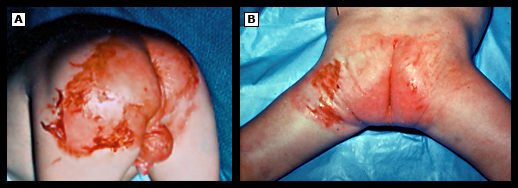

# Magnesium

## Role of magnesium as an antiarrhythmic

- The significance of Magnesium is debated at this [Source](https://www.ahajournals.org/doi/10.1161/CIRCEP.116.004521)
- but it does prolong PR intervals and increase the refractory period of anterograde conductioin at the AV node.  
  | | | | | |

# Nail changes

[Source](https://dermnetnz.org/topics/nail-terminology)  
#2020GM-JUL/Q32

> [!TIP] mnemonic  
> Beau lines - 'Bumps', 'Brake' - caused by any systemic or local insult 'putting the brakes' on nail growth.  
> Mees lines - caused by toxins, including arsenic  
> Muehrcke lines - caused by low protein

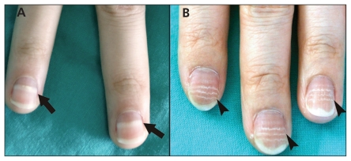

**Beau lines** and onychomadesis

- Caused by *Acute systemic illness stopping nail growth*: [Source](https://dermnetnz.org/topics/nail-terminology)
- may be caused by *infection*, *surgery*, *trauma*, Raynaud disease, pemphigus or chemotherapy (i.e., taxoids).
- - They are transverse *depressions* of the nail.

**Mees** lines:

- In Mees lines (**true leukonychia**) a change occurs in the colour of the nail with *no palpable ridges*.
- The insult causing Mees lines does not cause cessation of nail growth. Rather there is parakeratosis of the nail bed.
- Mees lines are associated with *arsenic* poisoning, *Hodgkin* lymphoma, *carcinoid* tumours and *chemotherapy* <- basically toxins and Hodgkin.

**Muehrcke** lines;

- These are caused by vascular congestion and blanch on pressure and DO not migrate with nail growth.
  - Muehrcke lines result from **liver disease**, **nephrotic syndrome**, **malnutrition** and **severe hypoalbuminemia**

| Nail sign | Associated disease |
| --- | --- |
| ❗Splinter haemorrhages❗ | Infective endocarditis; but also trauma, May systemic diseases, meningococcal disease, psitaccosis, histoplasmosis |
| Pitting | Psoriasis, Alopecia areata('spot baldness': hair loss in parts / all of body) |
| Onychorrhexis | *longitudinal* ridging of nails with brittleness. Aging, [[Dermatology#Lichen planus\|LP]], fungal infection |
| Longitudinal groove | wart beneath the nail, in the underlying nail bed, or mixoid cyst. |
| Horizontal groove | previous trauma |
| Onychogrphosis | Rams horn shapep nail; aging, psoriasis, trauma |
| Angel wing deformity | another sign of [[Dermatology#Lichen planus\|LP]] |
| Trachyonychia | Roughness of nails; Another sign of [[Dermatology#Lichen planus\|LP]] |
| Yellow nails | Many causes: yellow nail syndrome-> caused by lymphatic obstruction. Fungal infectino |
| Cont. | Also caused by psoriasis; lateral yellow streaks are due to onychomycosis |
| Salmon patch | Psoriatic arthritis |
| half and half nails | White proximal segment: chronic renal/kidney disease |
| Lontigudinal melonychia | Longitudinal pigmented lines; among others Peutz-Jeghers syndrome |
| Nail fold telangiectasia | Characteristic of *connective tissue disease* like **SLE** |
| Pterygium of nail | Bit of extra tissue; seen in LP. |

## Nail shape disorders

| Disorder | disease |
| --- | --- |
| Koilnychia | can be normal, iron deficiency, diabetes + others |

[figure not shown]

Main route is **percutaneous inoculation**. Inhalation and ingestion also possible.  
Tranmission *may* be through the inhaled route as well.  
Person to person transmission is extremely rare.  
Commonest : pneumonia (? a bad pneumonia);but virtually any organ is possible, including septic arthritis.  
CXR - *cavitational lesions, abscesses, necrotic lesions*, **mediastinal lymphadenopathy**  
📑In melioidosis specifically, laboratory studies may demonstrate **anemia**, **leukocytosis**, *hepatic* impairment, *renal* insufficiency, and **coagulopathy**  
The main therapeutic options for melioidosis include 📑beta-lactams (eg, **[ceftazidime**](https://www.uptodate.com/contents/ceftazidime-drug-information?search=melioidosis&topicRef=3136&source=see_link), certain beta-lactam+beta-lactamase inhibitor combinations), **carbapenems**, [trimethoprim-sulfamethoxazole](https://www.uptodate.com/contents/trimethoprim-sulfamethoxazole-co-trimoxazole-drug-information?search=melioidosis&topicRef=3136&source=see_link) (**TMP-SMX**), and [doxycycline](https://www.uptodate.com/contents/doxycycline-drug-information?search=melioidosis&topicRef=3136&source=see_link), depending on the phase of treatment.

> *B. pseudomallei* are intrinsically **resistant to penicillin, [ampicillin]**, first- and second-generation cephalosporins, gentamicin, tobramycin, and streptomycin. In vitro susceptibility testing of *B. pseudomallei* for quinolones generally show resistance or intermediate results, and disc diffusion techniques can give "false-sensitive results" .

# 📑Sarcoidosis

**Etiology unknown**.  
Can also involve **eyes** - uveitis, **skin** - lupus pernio.

> [!INFO] Lupus pernio

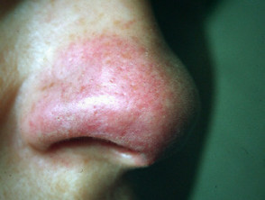

Lupus pernio = cutaneous sarcoidosis  
Lupus vulgaris = cutaneous tuberculosis

Heart can also be involved: Mild to life threatening spectrum.

- **Conduction:** Heart block and arrhythmias
- **Muscle**: Heart failure
- **Valves**: Valular dysfuntion
- simulated infarction
- **pericardial** disease

Renal involvement is uncommon.

Delirium is r**apid in onset** and **fluctuating in course**.  
- > Most studies have found the highest mortality in patients with the hypoactive subtype. [Source](https://www.ncbi.nlm.nih.gov/pmc/articles/PMC6398701/)

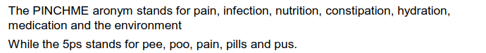

[Source](https://www.swslhd.health.nsw.gov.au/eods/pdf/Resources/4AT%20Notes%20pages.pdf) The 5P's correspond to the vowels ;)

#2022GM-MAYQ31  
#2020GM-JUL/Q

> [!INFO] Type 1 Vs. Type 2  
> Type 1: "more cysts, more frequent, more chromosomes"

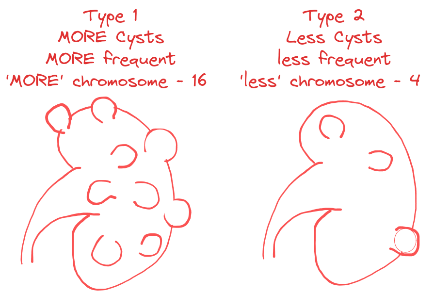

Mutations in **PKD1 gene** (on chromosome *16*) are responsible for *85% of cases*. Rest are by **PKD2 gene** (on chromosome *4*).

> [!INFO] Autosomal *recessive PCKD*  
> Due to #autosomal-Recessive mutations carried on chromosome 6. Much rarer than ADPKD.

PKD genes encode the **polycystin** proteins. Mutations of these cause **decreased** intracellular calcium in the *principal* cells of the collecting duct -> **dysoriented** cell division -> **cyst formation**.

*Polycystin 1 (in PKD1) is a regulator of tubular epithelial cell adhesion* and differentiation. *Polycystin 2 (in PKD2) is an ion channel*. These are required for function of **cilia** of the tubular epithelium which are in turn required for flow sensing. Impaired flow sensing causes a defect in proliferation and differentiation -> cysts.

Cyst formation occurs only in 5-10% of nephrons but that's enough to cause renomegaly.

**Risk factors for progressive renal disease**:

- *Male gender*
- *proteinuria* - although it's not a major feature of PCKD.
- **High urinary sodium excretion**
- **hypertension** - patients with larger kidneys tend to have hypertension.  
  🔴⚠️PKD1⚠️🔴 is more severe than 🟢PKD2🟢

> Since the cysts grow at the same rate in both forms, it is likely that the difference is due to a **higher number of cysts in type 1**, rather than a higher growth rate. [Source](https://www.news-medical.net/health/Genetics-of-Polycystic-Kidney-Disease.aspx)
- proteinuria -
- All patients with PCKD have a *mild concentrating defect* (one of the **earliest features of the diseaes** ) causing them to develop thirst, **polyuria**, frequency and nocturia.) - mechanism not known.
- For patients who *have a family history*
  - For young adults, > total of 3 cysts
  - For older adults(40 y/o and above), > 2 cysts in *each* kidney.
- For patients *without a family history*, there are no well defined imaging diagnostic criteria because solitary *or multiple* renal cysts are common, especially at age > 50%. Therefore, a cut-off of 10 or more cysts *per kidney* is reasonable for diagnosis of ADPKD.  
  Renal cancer occurs **only rarely** in PCKD. It may not even be more frequent than the general population. [Source](https://www.uptodate.com/contents/autosomal-dominant-polycystic-kidney-disease-adpkd-kidney-manifestations)
- **Cerebral** vasculature aneurysms
- **Hepatic** and **pancreatic** cysts
- **Valvular dysfunction** - MR and AR + coronary aneurysms
- **Colonic** diverticulae
- **Seminal** vesicle cysts
- Manage blood pressure with ACEi / ARB
- Restrict dietary sodium
- **Higher** fluid intake is recommended. (>3) -> prevents nephrolithiasis and suppresses ADH which may increase cyst growth.
- Tolvaptan - given for high risk patients; proven benefit. (because vasopressive promotes cellular proliferation). **Slows progress of disease**. ?does not induce regression? #2020GM-JUL/Q29
- Erythropoietin is actually not needed for treatment as Epo levels tend to be *higher* in PCKD patients. Probably stimulated secondary to local ischemia. [Source](https://www.uptodate.com/contents/autosomal-dominant-polycystic-kidney-disease-adpkd-kidney-manifestations)

> Janeway - painless, vascular phenomena;  
> Bacterial may be culture from them. [Source](https://dermnetnz.org/topics/osler-nodes-and-janeway-lesions)

*ALP and gamma GT may be elevated*.  
[[Miscellaneous respiratory medicine#Giant cell arteritis|Giant cell arteritis]] is seen in 30% of cases.  
#2020GM-JUL/Q30

- **IX:** NCNC **anaemia** and *elevated ESR*.
- Giving **steroids is ESSENTIAL**, since it can prevent vision loss due to ophthalmic artery ischemia.
- **Steroid should be given in MUCH HIGHER DOSES than in PMR**.

# 📑Serum sickness

Pathophysiology: Patient starts to produce antibodies to a *non-human proteins* that was introduced into the system, usually via some type of treatment. The antibodies bind the foreign protein and form antigen-antibody complexes. If they are not cleared, they deposit in tissues and the *synovial fluid*.

- Monoclonal antibodies *derived from animals*

# Recreational drugs and overdose

| Drug | Effects | Toxicity |  |
| --- | --- | --- | --- |
| **THC** | Feeling of relaxation and well-being; no aggression and recklessness like alcohol | relatively safe | Causes hyperpolarization and inhibits neutrotm release |
|  | Sounds and lights seem intense; sensory distortion + hallucination | Drowsiness, confusion |  |
|  | Sharpened sensory awareness |  |  |
|  | Above is similar to but milder than LSD. (no paranoid delusions like with LSD) |  |  |
|  | Impairement of motor coordination, short term memory, hypothermia, catalepsy,analgesia, |  |  |
|  | ⬆ appetite, antiemetic and analgesia |  |  |
|  | ❗Autonomic: Tachycardia, vasodilation (blood shot eyes),bronchodilation❗ |  |  |
|  | Highly lipophilic. Binds to fat and excretion continues for weeks after a single dose. |  |  |
| - | - | - | - |
| **Amphetamines** | All have similar pharmacological effects. | ⬆HR, ⬆BP | Releaes monoamines (dopamine and noradrenaline) |
| DL-amphetamine | Increased motor activity, euphoria, insomina, anorexia | Sweating, mydriasis |  |
| methamphetamine | Followed by depression and anxiety after dose wears off. | tachypnoea,Arrhythmia |  |
|  | Induce ❗Strong psychological dependence❗ | Flushing |  |
|  | Amphetamind psyhosis, similar to shizophrenia, develops after few days of use. |  |  |
|  | ->**hallucinations, paranoia, aggression** | Benzodiazepines + |  |
|  | ❗ Tolerance develops rapidly to eurphoric effects ❗ | Supportive Mx. |  |
|  | **There is no physical withdrawal syndrome** | Activated charcoal |  |
| - | - | - | - |
| **Cocaine** | Similar to amephatamines, less tendency for hallucinations and paranoia | ⬆HR, ⬆BP , Arrhythmia | Enhaces peripheral sypathetic activity |
|  | Euphoria, increased energy, feeling of ⬆strength, ⬆ pleasure, ⬆motor activity | Coronary vasospasm | Inhibits dopamine and serotonin reuptake |
|  | Psychological dependence+; uncertain about physical dependence. | ⬆temp, rhabdomyolysis |  |
|  | **No physical withdrawal syndrome**; but depression and fatigue after drug wears off. | Aortic dissection |  |
|  | ❗ Fetal malformation❗ and impaired fetal brain development | ICH, MI, isch. stroke |  |

## MDMA

(aka: ecstasy, molly)  
3,4-Methylenedioxymethamphetamine  
party drug  
Increased CNS levels of serotoning by inhibitin reuptake: Causes euphoria, alertness, 'empathogenic', but depression after the drug wears off.

> They should be evaluated for hyperthermia, dehydration, hyponatremia, seizures, hypertensive crises, cardiac dysrhythmias, and possible signs of serotonin syndrome

> Effects characterized by anxiety, *tachycardia*, and *elevated* blood pressures. Associated symptoms include *diaphoresis*, bruxism, jaw clenching, paresthesias, *dry mouth*, *increased psychomotor activity*, and *blurred vision*. Within 1 hour, these sympathomimetic effects are replaced by feelings of relaxation, euphoria, and increased empathy and communication.  
> Hallucinations are uncommon.  
> Toxicity: **hyperthermia**, **serotonin** syndrome,  
> Hyperthermia requires active cooling, antipyretics aren't useful.  
> (?dilutional) Hyponatremia can occur.  
> Seizures

## LSD

AKA acid; lysergic acid diethylamine.  
Extremely potent.  
Predominant effects are hallucinogenic.

- Hallucinations, disorted perception,
- Sensory modalities can be mixed up: sounds perceived as sights.
- The 'trips' can be good or bad, depending on the preceding mood.
- Flashbacks to bad drips are significant effect.  
  No physical withdrawal.  
  Physical efects : dilated pupils, tachycardia with palpitation, elevated blood pressure [Source](https://www.ncbi.nlm.nih.gov/books/NBK482407/)